# OCSVM Baseline Model

*Created by Holger Buech, Q1/2019*

**Description**

Reimplemenation of a OCSVM approach to Continuous Authentication described by [1]. Used as baseline model for futher experiments.

**Purpose**

- Get basic idea about authentication performance using raw data
- Verify results of [1]

**Data Sources**

- [H-MOG Dataset](http://www.cs.wm.edu/~qyang/hmog.html)  
  (Downloaded beforehand using ./src/data/make_dataset.py, stored in ./data/external/hmog_dataset/ and converted to ./data/processed/hmog_dataset.hdf5)

**References**

[1] Centeno, M. P. et al. (2018): Mobile Based Continuous Authentication Using Deep Features. Proceedings of the 2^nd International Workshop on Embedded and Mobile Deep Learning (EMDL), 2018, 19-24.

**Table of Contents**

**1 - Preparations**  
1.1 - Imports  
1.2 - Configuration  
1.3 - Experiment Parameters  
1.4 - Select Approach

**2 - Data Preparations**  
2.1 - Load Dataset  
2.2 - Normalize Features (if global)  
2.3 - Split Dataset for Valid/Test  
2.4 - Check Splits  
2.5 - Reshape Features

**3 - Hyperparameter Optimization**  
3.1 - Load cached Data  
3.2 - Search for Parameters  
3.3 - Inspect Search Results

**4 - Testing**  
4.1 - Load cached Data  
4.2 - Evaluate Authentication Performance  
4.3 - Evaluate increasing Training Set Size (Training Delay)  
4.4 - Evaluate increasing Test Set Size (Detection Delay)

## 1. Preparations

### 1.1 Imports

```python
# Standard
from pathlib import Path
import os
import sys
import dataclasses
import math
import warnings

# Extra
import pandas as pd
import numpy as np
from sklearn.svm import OneClassSVM
from sklearn.model_selection import cross_validate, RandomizedSearchCV
import statsmodels.stats.api as sms
from tqdm.auto import tqdm
import seaborn as sns
import matplotlib.pyplot as plt
from IPython.display import display

# Custom `DatasetLoader`class for easier loading and subsetting data from the datasets.
module_path = os.path.abspath(os.path.join(".."))  # supposed to be parent folder
if module_path not in sys.path:
    sys.path.append(module_path)
from src.utility.dataset_loader_hdf5 import DatasetLoader

# Global utitlity functions are in separate notebook
%run utils.ipynb
```

### 1.2 Configuration

```python
# Various Settings
SEED = 712  # Used for every random function
HMOG_HDF5 = Path.cwd().parent / "data" / "processed" / "hmog_dataset.hdf5"
EXCLUDE_COLS = ["sys_time"]
CORES = -1

# For plots and CSVs
OUTPUT_PATH = Path.cwd() / "output" / "chapter-6-1-3-ocsvm"
OUTPUT_PATH.mkdir(parents=True, exist_ok=True)
REPORT_PATH = Path.cwd().parent / "reports" / "figures" # Figures for thesis

# Plotting
%matplotlib inline
utils_set_output_style()
```

```python
# Workaround to remove ugly spacing between progress bars
HTML("<style>.p-Widget.jp-OutputPrompt.jp-OutputArea-prompt:empty{padding: 0;border: 0;} div.output_subarea{padding:0;}</style>")
```

### 1.3 Experiment Parameters

Selection of parameters set that had been tested in this notebook. Select one of them to reproduce results.

```python
@dataclasses.dataclass
class ExperimentParameters:
    """Contains all relevant parameters to run an experiment."""

    name: str  # Name of Parameter set. Used as identifier for charts etc.
    frequency: int
    max_subjects: int
    max_test_subjects: int
    seconds_per_subject_train: float
    seconds_per_subject_test: float
    task_types: list  # Limit scenarios to [1, 3, 5] for sitting or [2, 4, 6] for walking, or don't limit (None)
    window_size: int  # After resampling
    step_width: int  # After resampling
    scaler: str  # {"std", "robust", "minmax"}
    scaler_scope: str  # {"subject", "session"}
    scaler_global: bool  # fit transform scale on all data (True) or fit on training only (False)
    ocsvm_nu: float  # Best value found in random search, used for final model
    ocsvm_gamma: float  # Best value found in random search, used for final model
    feature_cols: list  # Columns used as features
    exclude_subjects: list  # Don't load data from those users

    # Calculated values
    def __post_init__(self):
        # HDF key of table:
        self.table_name = f"sensors_{self.frequency}hz"

        # Number of samples per _session_ used for training:
        self.samples_per_subject_train = math.ceil(
            (self.seconds_per_subject_train * 100)
            / (100 / self.frequency)
            / self.window_size
        )

        # Number of samples per _session_ used for testing:
        self.samples_per_subject_test = math.ceil(
            (self.seconds_per_subject_test * 100)
            / (100 / self.frequency)
            / self.window_size
        )



# INSTANCES
# ===========================================================

# NAIVE_APPROACH
# -----------------------------------------------------------
NAIVE_MINMAX_OCSVM = ExperimentParameters(
    name="NAIVE-MINMAX_OCSVM",
    frequency=100,
    max_subjects=90,
    max_test_subjects=30,
    seconds_per_subject_train=67.5,
    seconds_per_subject_test=67.5,
    task_types=None,
    window_size=50,
    step_width=50,
    scaler="minmax",
    scaler_scope="subject",
    scaler_global=True,
    ocsvm_nu=0.086,
    ocsvm_gamma=0.091,
    feature_cols=[
        "acc_x",
        "acc_y",
        "acc_z",
        "gyr_x",
        "gyr_y",
        "gyr_z",
        "mag_x",
        "mag_y",
        "mag_z",
    ],
    exclude_subjects=[
        "733162",  # No 24 sessions
        "526319",  # ^
        "796581",  # ^
        "539502",  # Least amount of sensor values
        "219303",  # ^
        "737973",  # ^
        "986737",  # ^
        "256487",  # Most amount of sensor values
        "389015",  # ^
        "856401",  # ^
    ],
)

# VALID_APPROACH
# -----------------------------------------------------------
VALID_MINMAX_OCSVM = dataclasses.replace(
    NAIVE_MINMAX_OCSVM,
    name="VALID-MINMAX-OCSVM",
    scaler_global=False,
    ocsvm_nu=0.165,
    ocsvm_gamma=0.039,
)

# NAIVE_ROBUST_APPROACH
# -----------------------------------------------------------
NAIVE_ROBUST_OCSVM = dataclasses.replace(
    NAIVE_MINMAX_OCSVM,
    name="NAIVE-ROBUST-OCSVM",
    scaler="robust",
    scaler_global=True,
    ocsvm_nu=0.153,
    ocsvm_gamma=0.007,  # below median, selected by chart
)

# ROBUST_APPROACH (VALID)
# -----------------------------------------------------------
VALID_ROBUST_OCSVM = dataclasses.replace(
    NAIVE_MINMAX_OCSVM,
    name="VALID-ROBUST-OCSVM",
    scaler="robust",
    scaler_global=False,
    ocsvm_nu=0.098,
    ocsvm_gamma=0.003,
)
```

### 1.4 Select approach

Select the parameters to use for current notebook execution here!

```python
P = NAIVE_MINMAX_OCSVM
```

**Overview of current Experiment Parameters:**

```python
utils_ppp(P)
```

|  | Value |
| --- | --- |
| exclude_subjects | [733162, 526319, 796581, 539502, 219303, 73797... |
| feature_cols | [acc_x, acc_y, acc_z, gyr_x, gyr_y, gyr_z, mag... |
| frequency | 100 |
| max_subjects | 90 |
| max_test_subjects | 30 |
| name | NAIVE-MINMAX_OCSVM |
| ocsvm_gamma | 0.091 |
| ocsvm_nu | 0.086 |
| scaler | minmax |
| scaler_global | True |
| scaler_scope | subject |
| seconds_per_subject_test | 67.5 |
| seconds_per_subject_train | 67.5 |
| step_width | 50 |
| task_types | None |
| window_size | 50 |

## 2. Data Preparation

### 2.1 Load Dataset

```python
hmog = DatasetLoader(
    hdf5_file=HMOG_HDF5,
    table_name=P.table_name,
    max_subjects=P.max_subjects,
    task_types=P.task_types,
    exclude_subjects=P.exclude_subjects,
    exclude_cols=EXCLUDE_COLS,
    seed=SEED,
)

hmog.data_summary()
```

|  | DataFrame | Memory (MB) | Rows | Columns | Subjects | Sessions |
| --- | --- | --- | --- | --- | --- | --- |
| 0 | all | 11155.52 | 112475144 | 12 | 90 | 2160 |
| 1 | index | 0.08 | 2160 | 4 | 90 | 2160 |

### 2.2 Normalize features (if global)

Used here for naive approach (before splitting into test and training sets). Otherwise it's used during generate_pairs() and respects train vs. test borders.

```
Normalize all data before splitting into train and test sets...
Before Scaling:
```

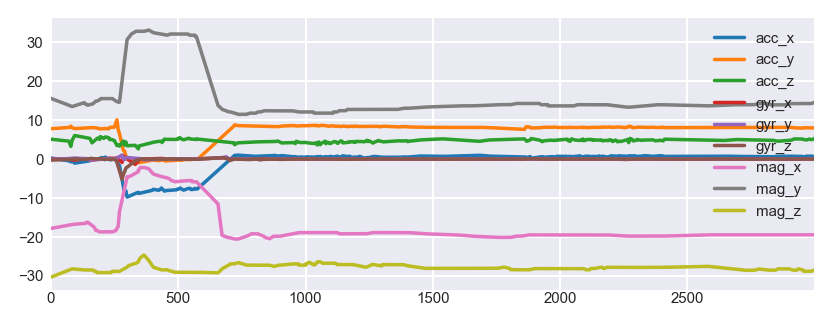

```
After Scaling:
```

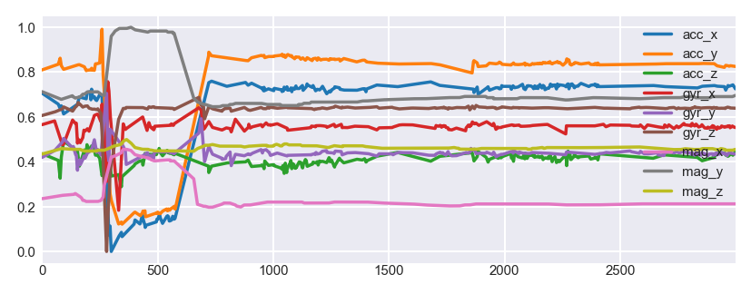

```python
if P.scaler_global:
    print("Normalize all data before splitting into train and test sets...")
    hmog.all, _ = utils_custom_scale(
        hmog.all,
        scale_cols=P.feature_cols,
        feature_cols=P.feature_cols,
        scaler_name=P.scaler,
        scope=P.scaler_scope,
        plot=True,
    )
else:
    print("Skipped, normalize after splitting.")
```

### 2.3 Split Dataset for Valid/Test

In two splits: one used during hyperparameter optimization, and one used during testing.

The split is done along the subjects: All sessions of a single subject will either be in the validation split or in the testing split, never in both.

```python
hmog.split_train_test(n_test_subjects=P.max_test_subjects)
hmog.data_summary()
```

|  | DataFrame | Memory (MB) | Rows | Columns | Subjects | Sessions |
| --- | --- | --- | --- | --- | --- | --- |
| 0 | index | 0.08 | 2160 | 4 | 90 | 2160 |
| 1 | train | 7539.22 | 76013863 | 12 | 60 | 1440 |
| 2 | test | 3616.31 | 36461281 | 12 | 30 | 720 |

### 2.4 Check Splits

```python
utils_split_report(hmog.train)
```

```
Unique subjects: 60
Unique sessions: 1440

Head:
```

[output not shown]

```
Sessions' Task Types per subject:
```

| subject | 100669 | 171538 | 201848 | 207696 | 220962 | 240168 | 257279 | 261313 | 277905 | 278135 | 326223 | 342329 | 352716 | 366286 | 368258 | 395129 | 396697 | 398248 | 431312 | 472761 | 489146 | 525584 | 527796 | 538363 | 540641 | 554303 | 556357 | 578526 | 588087 | … |
| --- | --- | --- | --- | --- | --- | --- | --- | --- | --- | --- | --- | --- | --- | --- | --- | --- | --- | --- | --- | --- | --- | --- | --- | --- | --- | --- | --- | --- | --- | --- |
| 1 | 4 | 4 | 4 | 4 | 4 | 4 | 4 | 4 | 4 | 4 | 4 | 4 | 4 | 4 | 4 | 4 | 4 | 4 | 4 | 4 | 4 | 4 | 4 | 4 | 4 | 4 | 4 | 4 | 4 | … |
| 2 | 4 | 4 | 4 | 4 | 4 | 4 | 4 | 4 | 4 | 4 | 4 | 4 | 4 | 4 | 4 | 4 | 4 | 4 | 4 | 4 | 4 | 4 | 4 | 4 | 4 | 4 | 4 | 4 | 4 | … |
| 3 | 4 | 4 | 4 | 4 | 4 | 4 | 4 | 4 | 4 | 4 | 4 | 4 | 4 | 4 | 4 | 4 | 4 | 4 | 4 | 4 | 4 | 4 | 4 | 4 | 4 | 4 | 4 | 4 | 4 | … |
| 4 | 4 | 4 | 4 | 4 | 4 | 4 | 4 | 4 | 4 | 4 | 4 | 4 | 4 | 4 | 4 | 4 | 4 | 4 | 4 | 4 | 4 | 4 | 4 | 4 | 4 | 4 | 4 | 4 | 4 | … |
| 5 | 4 | 4 | 4 | 4 | 4 | 4 | 4 | 4 | 4 | 4 | 4 | 4 | 4 | 4 | 4 | 4 | 4 | 4 | 4 | 4 | 4 | 4 | 4 | 4 | 4 | 4 | 4 | 4 | 4 | … |
| 6 | 4 | 4 | 4 | 4 | 4 | 4 | 4 | 4 | 4 | 4 | 4 | 4 | 4 | 4 | 4 | 4 | 4 | 4 | 4 | 4 | 4 | 4 | 4 | 4 | 4 | 4 | 4 | 4 | 4 | … |

```python
utils_split_report(hmog.test)
```

```
Unique subjects: 30
Unique sessions: 720

Head:
```

|  | acc_x | acc_y | acc_z | gyr_x | gyr_y | gyr_z | mag_x | mag_y | mag_z | subject | session | task_type |
| --- | --- | --- | --- | --- | --- | --- | --- | --- | --- | --- | --- | --- |
| 0 | 0.344675 | 0.544954 | 0.552652 | 0.564008 | 0.475771 | 0.508112 | 0.607597 | 0.685268 | 0.184064 | 151985 | 151985_session_1 | 1 |
| 1 | 0.341707 | 0.556562 | 0.531088 | 0.561431 | 0.476262 | 0.515021 | 0.610130 | 0.685268 | 0.185821 | 151985 | 151985_session_1 | 1 |
| 2 | 0.341663 | 0.555746 | 0.532176 | 0.558853 | 0.476753 | 0.521931 | 0.610130 | 0.685268 | 0.185821 | 151985 | 151985_session_1 | 1 |
| 3 | 0.341619 | 0.554929 | 0.533264 | 0.555062 | 0.473790 | 0.520065 | 0.610130 | 0.685268 | 0.185821 | 151985 | 151985_session_1 | 1 |
| 4 | 0.341574 | 0.554112 | 0.534353 | 0.550971 | 0.472380 | 0.518451 | 0.610130 | 0.685268 | 0.185821 | 151985 | 151985_session_1 | 1 |

```
Sessions' Task Types per subject:
```

| subject | 151985 | 180679 | 186676 | 218719 | 248252 | 264325 | 336172 | 405035 | 501973 | 553321 | 561993 | 579284 | 663153 | 675397 | 717868 | 720193 | 751131 | 771782 | 785873 | 799296 | 803262 | 808022 | 841866 | 862649 | 865881 | 893198 | 913228 | 937904 | 962159 | … |
| --- | --- | --- | --- | --- | --- | --- | --- | --- | --- | --- | --- | --- | --- | --- | --- | --- | --- | --- | --- | --- | --- | --- | --- | --- | --- | --- | --- | --- | --- | --- |
| 1 | 4 | 4 | 4 | 4 | 4 | 4 | 4 | 4 | 4 | 4 | 4 | 4 | 4 | 4 | 4 | 4 | 4 | 4 | 4 | 4 | 4 | 4 | 4 | 4 | 4 | 4 | 4 | 4 | 4 | … |
| 2 | 4 | 4 | 4 | 4 | 4 | 4 | 4 | 4 | 4 | 4 | 4 | 4 | 4 | 4 | 4 | 4 | 4 | 4 | 4 | 4 | 4 | 4 | 4 | 4 | 4 | 4 | 4 | 4 | 4 | … |
| 3 | 4 | 4 | 4 | 4 | 4 | 4 | 4 | 4 | 4 | 4 | 4 | 4 | 4 | 4 | 4 | 4 | 4 | 4 | 4 | 4 | 4 | 4 | 4 | 4 | 4 | 4 | 4 | 4 | 4 | … |
| 4 | 4 | 4 | 4 | 4 | 4 | 4 | 4 | 4 | 4 | 4 | 4 | 4 | 4 | 4 | 4 | 4 | 4 | 4 | 4 | 4 | 4 | 4 | 4 | 4 | 4 | 4 | 4 | 4 | 4 | … |
| 5 | 4 | 4 | 4 | 4 | 4 | 4 | 4 | 4 | 4 | 4 | 4 | 4 | 4 | 4 | 4 | 4 | 4 | 4 | 4 | 4 | 4 | 4 | 4 | 4 | 4 | 4 | 4 | 4 | 4 | … |
| 6 | 4 | 4 | 4 | 4 | 4 | 4 | 4 | 4 | 4 | 4 | 4 | 4 | 4 | 4 | 4 | 4 | 4 | 4 | 4 | 4 | 4 | 4 | 4 | 4 | 4 | 4 | 4 | 4 | 4 | … |

### 2.5 Reshape Features

**Reshape & store Set for Validation:**

```python
df_train_valid = utils_reshape_features(
    hmog.train,
    feature_cols=P.feature_cols,
    window_size=P.window_size,
    step_width=P.step_width,
)

# Clean memory
del hmog.train
%reset_selective -f hmog.train

print("Validation data after reshaping:")
display(df_train_valid.head())

# Store iterim data
df_train_valid.to_msgpack(OUTPUT_PATH / "df_train_valid.msg")

# Clean memory
%reset_selective -f df_train_valid
```

```
Validation data after reshaping:
```

|  | X | subject | session | task_type |
| --- | --- | --- | --- | --- |
| 0 | [[0.7060011741747644, 0.8099849141167745, 0.43... | 100669 | 100669_session_1 | 1 |
| 1 | [[0.6710413880618208, 0.8278993974312248, 0.41... | 100669 | 100669_session_1 | 1 |
| 2 | [[0.6185057198998293, 0.8146750530352369, 0.48... | 100669 | 100669_session_1 | 1 |
| 3 | [[0.6545577005134453, 0.8309701105188976, 0.45... | 100669 | 100669_session_1 | 1 |
| 4 | [[0.7108375910890761, 0.8090111810466953, 0.46... | 100669 | 100669_session_1 | 1 |

**Reshape & store Set for Testing:**

```python
df_train_test = utils_reshape_features(
    hmog.test,
    feature_cols=P.feature_cols,
    window_size=P.window_size,
    step_width=P.step_width,
)

del hmog.test
%reset_selective -f hmog.test

print("Testing data after reshaping:")
display(df_train_test.head())

# Store iterim data
df_train_test.to_msgpack(OUTPUT_PATH / "df_train_test.msg")

# Clean memory
%reset_selective -f df_train_test
```

```
Testing data after reshaping:
```

|  | X | subject | session | task_type |
| --- | --- | --- | --- | --- |
| 0 | [[0.3446752700161634, 0.5449544894080571, 0.55... | 151985 | 151985_session_1 | 1 |
| 1 | [[0.34191710603158537, 0.5496431045892561, 0.5... | 151985 | 151985_session_1 | 1 |
| 2 | [[0.34105496660216983, 0.5814174005961457, 0.5... | 151985 | 151985_session_1 | 1 |
| 3 | [[0.32170437669227814, 0.6046004764327177, 0.5... | 151985 | 151985_session_1 | 1 |
| 4 | [[0.31347212205865005, 0.6150040729110153, 0.5... | 151985 | 151985_session_1 | 1 |

```python
# Clean Memory
%reset_selective -f df_
```

## 3. Hyperparameter Optimization

### 3.1 Load cached Data

Only the split dedicated for hyperparameter optimization is loaded

```python
df_train_valid = pd.read_msgpack(OUTPUT_PATH / "df_train_valid.msg")
df_train_valid.head()
```

|  | X | subject | session | task_type |
| --- | --- | --- | --- | --- |
| 0 | ((0.7060011741747644, 0.8099849141167745, 0.43... | 100669 | 100669_session_1 | 1 |
| 1 | ((0.6710413880618208, 0.8278993974312248, 0.41... | 100669 | 100669_session_1 | 1 |
| 2 | ((0.6185057198998293, 0.8146750530352369, 0.48... | 100669 | 100669_session_1 | 1 |
| 3 | ((0.6545577005134453, 0.8309701105188976, 0.45... | 100669 | 100669_session_1 | 1 |
| 4 | ((0.7108375910890761, 0.8090111810466953, 0.46... | 100669 | 100669_session_1 | 1 |

### 3.2 Search for Parameters

```python
param_dist = {"gamma": np.logspace(-3, 3), "nu": np.linspace(0.0001, 0.3)}
warnings.filterwarnings("ignore")
df_results = None  # Will be filled with randomsearch scores
for run in tqdm(range(3)):
    for df_cv_scenarios, owner, impostors in tqdm(
        utils_generate_cv_scenarios(
            df_train_valid,
            samples_per_subject_train=P.samples_per_subject_train,
            samples_per_subject_test=P.samples_per_subject_test,
            seed=SEED + run,
            scaler=P.scaler,
            scaler_global=P.scaler_global,
            scaler_scope=P.scaler_scope,
            feature_cols=P.feature_cols,
        ),
        desc="Owner",
        total=df_train_valid["subject"].nunique(),
        leave=False,
    ):
        X = np.array(df_cv_scenarios["X"].values.tolist())
        X = X.reshape(X.shape[-3], -1)  # flatten windows
        y = df_cv_scenarios["label"].values
        train_valid_cv = utils_create_cv_splits(df_cv_scenarios["mask"].values, SEED)
        model = OneClassSVM(kernel="rbf")

        random_search = RandomizedSearchCV(
            model,
            param_distributions=param_dist,
            cv=train_valid_cv,
            n_iter=80,
            n_jobs=CORES,
            refit=False,
            scoring={"eer": utils_eer_scorer, "accuracy": "accuracy"},
            verbose=0,
            return_train_score=False,
            iid=False,
            random_state=SEED,
        )
        random_search.fit(X, y)
        df_report = utils_cv_report(random_search, owner, impostors)
        df_report["run"] = run
        df_results = pd.concat([df_results, df_report], sort=False)

df_results.to_csv(OUTPUT_PATH / f"{P.name}_random_search_results.csv", index=False)
```

### 3.3 Inspect Search Results

**Raw Results & Stats:**

```python
df_results = pd.read_csv(OUTPUT_PATH / f"{P.name}_random_search_results.csv")
print("Example from result table (head):")
display(
    df_results[df_results["rank_test_eer"] == 1]
    .sort_values("mean_test_eer")
    .head(10)
)
print("\n\n\nMost relevant statistics:")
display(
    df_results[df_results["rank_test_eer"] == 1][
        [
            "mean_fit_time",
            "param_nu",
            "param_gamma",
            "mean_test_accuracy",
            "std_test_accuracy",
            "mean_test_eer",
            "std_test_eer",
        ]
    ].describe()
)
```

```
Example from result table (head):
```

|  | mean_fit_time | std_fit_time | mean_score_time | std_score_time | param_nu | param_gamma | 777078_test_eer | 763813_test_eer | 693572_test_eer | 220962_test_eer | 278135_test_eer | 261313_test_eer | 892687_test_eer | 879155_test_eer | 395129_test_eer | 525584_test_eer | 865501_test_eer | 966655_test_eer | 396697_test_eer | 326223_test_eer | 342329_test_eer | 657486_test_eer | 872895_test_eer | 876011_test_eer | 366286_test_eer | 984799_test_eer | 489146_test_eer | 973891_test_eer | 918136_test_eer | … |
| --- | --- | --- | --- | --- | --- | --- | --- | --- | --- | --- | --- | --- | --- | --- | --- | --- | --- | --- | --- | --- | --- | --- | --- | --- | --- | --- | --- | --- | --- | --- |
| 2540 | 0.001853 | 0.005051 | 0.001589 | 0.004721 | 0.042943 | 0.012649 | 0.000000 | 0.000000 | 0.000000 | 0.000000 | 0.000000 | 0.000000 | 0.000000 | 0.000000 | 0.000000 | 0.000000 | 0.000000 | 0.000000 | 0.000000 | 0.000000 | 0.000000 | 0.020408 | 0.000000 | 0.000000 | 0.000000 | 0.000000 | 0.000000 | 0.000000 | 0.000000 | … |
| 29 | 0.003442 | 0.006474 | 0.001853 | 0.005051 | 0.085786 | 0.091030 | 0.142857 | 0.000000 | 0.000000 | 0.000000 | 0.000000 | 0.000000 | 0.000000 | 0.000000 | 0.000000 | 0.000000 | 0.000000 | 0.000000 | 0.058824 | 0.000000 | 0.000000 | 0.000000 | 0.040000 | 0.000000 | 0.076923 | 0.000000 | 0.040000 | 0.000000 | 0.000000 | … |
| 6684 | 0.005296 | 0.007395 | 0.003971 | 0.006801 | 0.251037 | 0.022230 | 0.020408 | 0.020408 | 0.020408 | 0.020408 | 0.020408 | 0.020408 | 0.020408 | 0.020408 | 0.020408 | 0.020408 | 0.020408 | NaN | 0.020408 | 0.020408 | 0.020408 | 0.020408 | 0.020408 | 0.020408 | 0.020408 | 0.020408 | 0.020408 | 0.020408 | 0.020408 | … |
| 6706 | 0.004501 | 0.007075 | 0.004236 | 0.006945 | 0.244916 | 0.022230 | 0.020408 | 0.020408 | 0.020408 | 0.020408 | 0.020408 | 0.020408 | 0.020408 | 0.020408 | 0.020408 | 0.020408 | 0.020408 | NaN | 0.020408 | 0.020408 | 0.020408 | 0.020408 | 0.020408 | 0.020408 | 0.020408 | 0.020408 | 0.020408 | 0.020408 | 0.020408 | … |
| 10318 | 0.003707 | 0.006645 | 0.002648 | 0.005861 | 0.134749 | 0.091030 | 0.020408 | 0.020408 | 0.020408 | 0.020408 | 0.020833 | 0.020408 | 0.020408 | 0.020408 | 0.020408 | 0.020408 | 0.020408 | 0.020408 | 0.020408 | 0.020408 | 0.020408 | 0.020408 | NaN | 0.020408 | 0.020408 | 0.020408 | 0.020408 | 0.020408 | 0.020408 | … |
| 10221 | 0.001058 | 0.003924 | 0.000794 | 0.003430 | 0.030702 | 0.001326 | 0.000000 | 0.058824 | 0.076923 | 0.127273 | 0.058824 | 0.000000 | 0.000000 | 0.094340 | 0.000000 | 0.000000 | 0.000000 | 0.000000 | 0.000000 | NaN | 0.020408 | 0.000000 | 0.000000 | 0.020408 | 0.000000 | 0.000000 | 0.000000 | 0.000000 | 0.000000 | … |
| 3549 | 0.001853 | 0.005050 | 0.002912 | 0.006083 | 0.085786 | 0.091030 | 0.020408 | 0.060000 | 0.060000 | 0.020408 | 0.078431 | 0.020408 | 0.020408 | 0.020408 | 0.020408 | 0.020408 | 0.020408 | 0.020408 | 0.020408 | 0.020408 | 0.020408 | 0.020833 | 0.129630 | 0.020408 | 0.020408 | 0.020408 | 0.040816 | 0.020408 | 0.020408 | … |
| 14311 | 0.002912 | 0.006084 | 0.004766 | 0.007193 | 0.165351 | 0.039069 | 0.040000 | 0.333333 | 0.040000 | 0.040000 | 0.040816 | NaN | 0.040000 | 0.040000 | 0.040000 | 0.040816 | 0.040000 | 0.040000 | 0.040000 | 0.040000 | 0.040000 | 0.040816 | 0.040000 | 0.040000 | 0.115385 | 0.040000 | 0.040000 | 0.080000 | 0.040000 | … |
| 6610 | 0.004766 | 0.007193 | 0.003442 | 0.006475 | 0.195953 | 0.051795 | 0.098039 | 0.040000 | 0.040816 | 0.040000 | 0.040000 | 0.040000 | 0.040000 | NaN | 0.040000 | 0.040000 | 0.040000 | 0.040000 | 0.040000 | 0.080000 | 0.040816 | 0.040000 | 0.040000 | 0.040000 | 0.040000 | 0.040000 | 0.040000 | 0.040000 | 0.061224 | … |
| 10158 | 0.003971 | 0.006801 | 0.002383 | 0.005617 | 0.134749 | 0.091030 | 0.040000 | 0.040000 | 0.040000 | 0.040000 | 0.040000 | 0.040000 | 0.206897 | 0.040000 | 0.040000 | 0.040000 | 0.040000 | 0.040000 | 0.040000 | 0.040000 | 0.040000 | 0.040000 | 0.040000 | 0.148148 | 0.040816 | 0.040000 | 0.132075 | 0.040000 | 0.040000 | … |

```
Most relevant statistics:
```

|  | mean_fit_time | param_nu | param_gamma | mean_test_accuracy | std_test_accuracy | mean_test_eer | std_test_eer |
| --- | --- | --- | --- | --- | --- | --- | --- |
| count | 187.000000 | 187.000000 | 187.000000 | 187.000000 | 187.000000 | 187.000000 | 187.000000 |
| mean | 0.003099 | 0.110496 | 0.076236 | 0.880846 | 0.055546 | 0.165095 | 0.050579 |
| std | 0.001058 | 0.044191 | 0.049552 | 0.064408 | 0.037393 | 0.076251 | 0.038227 |
| min | 0.000265 | 0.024582 | 0.001000 | 0.677966 | 0.000000 | 0.003315 | 0.000000 |
| 25% | 0.002383 | 0.085786 | 0.039069 | 0.833510 | 0.028435 | 0.109882 | 0.018981 |
| 50% | 0.002912 | 0.085786 | 0.091030 | 0.884534 | 0.053288 | 0.163055 | 0.045617 |
| 75% | 0.003706 | 0.134749 | 0.091030 | 0.930879 | 0.080473 | 0.218580 | 0.076042 |
| max | 0.006619 | 0.287759 | 0.281177 | 0.998234 | 0.163843 | 0.363706 | 0.151318 |

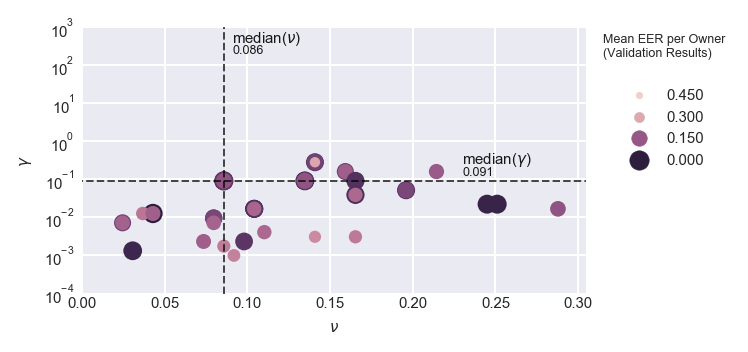

```python
utils_plot_randomsearch_results(df_results, n_top=1)
utils_save_plot(plt, REPORT_PATH / f"buech2019-ocsvm-{P.name.lower()}-parameters.pdf")
```

**Note:** Using median to select the best parameters, as mean is strongly influenced by outliers.

```python
# Clean Memory
%reset_selective -f df_
```

## 4. Testing

### 4.1 Load cached Data

During testing, a split with different users than used for hyperparameter optimization is used:

```python
df_train_test = pd.read_msgpack(OUTPUT_PATH / "df_train_test.msg")
```

### 4.2 Evaluate Authentication Performance

- Using Testing Split, Scenario Cross Validation, and multiple runs to lower impact of random session/sample selection.

```python
df_results = None  # Will be filled with cv scores

for i in tqdm(range(5), desc="Run", leave=False):  # Run whole test 5 times
    for df_cv_scenarios, owner, impostors in tqdm(
        utils_generate_cv_scenarios(
            df_train_test,
            samples_per_subject_train=P.samples_per_subject_train,
            samples_per_subject_test=P.samples_per_subject_test,
            seed=SEED + i,  # Change seed for different runs
            scaler=P.scaler,
            scaler_global=P.scaler_global,
            scaler_scope=P.scaler_scope,
            feature_cols=P.feature_cols,
        ),
        desc="Owner",
        total=df_train_test["subject"].nunique(),
        leave=False,
    ):
        X = np.array(df_cv_scenarios["X"].values.tolist())
        X = X.reshape(X.shape[-3], -1)  # flatten windows
        y = df_cv_scenarios["label"].values
        train_test_cv = utils_create_cv_splits(df_cv_scenarios["mask"].values, SEED)

        model = OneClassSVM(kernel="rbf", nu=P.ocsvm_nu, gamma=P.ocsvm_gamma)

        scores = cross_validate(
            model,
            X,
            y,
            cv=train_test_cv,
            scoring={
                "eer": utils_eer_scorer,
                "accuracy": "accuracy",
                "precision": "precision",
                "recall": "recall",
            },
            n_jobs=CORES,
            verbose=0,
            return_train_score=True,
        )
        df_score = pd.DataFrame(scores)
        df_score["owner"] = owner
        df_score["train_eer"] = df_score["train_eer"].abs()  # Revert scorer's signflip
        df_score["test_eer"] = df_score["test_eer"].abs()
        df_results = pd.concat([df_results, df_score], axis=0)

df_results.to_csv(OUTPUT_PATH / f"{P.name}_test_results.csv", index=False)

df_results.head()
```

|  | fit_time | score_time | test_eer | train_eer | test_accuracy | train_accuracy | test_precision | train_precision | test_recall | train_recall | owner |
| --- | --- | --- | --- | --- | --- | --- | --- | --- | --- | --- | --- |
| 0 | 0.0 | 0.000000 | 0.333333 | 1.818989e-12 | 0.677083 | 0.895833 | 0.688889 | 1.0 | 0.645833 | 0.895833 | 808022 |
| 1 | 0.0 | 0.015623 | 0.303571 | 1.818989e-12 | 0.729167 | 0.895833 | 0.775000 | 1.0 | 0.645833 | 0.895833 | 808022 |
| 2 | 0.0 | 0.000000 | 0.261538 | 1.818989e-12 | 0.822917 | 0.895833 | 1.000000 | 1.0 | 0.645833 | 0.895833 | 808022 |
| 3 | 0.0 | 0.015621 | 0.367347 | 1.818989e-12 | 0.635417 | 0.895833 | 0.632653 | 1.0 | 0.645833 | 0.895833 | 808022 |
| 4 | 0.0 | 0.000000 | 0.500000 | 1.818989e-12 | 0.500000 | 0.895833 | 0.500000 | 1.0 | 0.645833 | 0.895833 | 808022 |

**Load Results from "EER & Accuracy" evaluation & prepare for plotting:**

```python
df_results = pd.read_csv(OUTPUT_PATH / f"{P.name}_test_results.csv")
df_plot = df_results.rename(
    columns={"test_accuracy": "Test Accuracy", "test_eer": "Test EER", "owner": "Owner"}
).astype({"Owner": str})
```

**Plot Distribution of Accuracy per subject:**

```
Overall mean: 0.8635
```

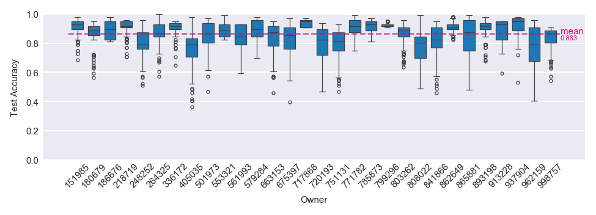

```python
fig = utils_plot_acc_eer_dist(df_plot, "Test Accuracy")
utils_save_plot(plt, REPORT_PATH / f"buech2019-ocsvm-{P.name.lower()}-acc.pdf")
```

```
Overall mean: 0.1879
```

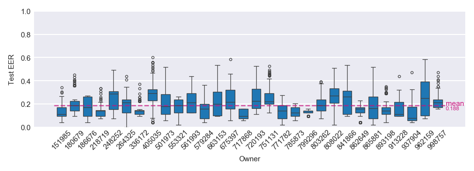

```python
fig = utils_plot_acc_eer_dist(df_plot, "Test EER")
utils_save_plot(plt, REPORT_PATH / f"buech2019-ocsvm-{P.name.lower()}-eer.pdf")
```

### 4.3 Evaluate increasing Training Set Size (Training Delay)

- Testing different amounts of samples in training set
- Using Testing Split, Scenario Cross Validation, and multiple runs to lower impact of random session/sample selection.

```python
training_set_sizes = [2, 4, 6, 8, 20, 60, 120, 180, 250, 350, 500, 750]

df_results = None  # Will be filled with cv scores
for i in tqdm(range(5), desc="Run", leave=False):
    for n_train_samples in tqdm(training_set_sizes, desc="Train Size", leave=False):
        for df_cv_scenarios, owner, impostors in tqdm(
            utils_generate_cv_scenarios(
                df_train_test,
                samples_per_subject_train=P.samples_per_subject_train,
                samples_per_subject_test=P.samples_per_subject_test,
                limit_train_samples=n_train_samples,  # samples overall
                seed=SEED + i,  # Change seed for different runs
                scaler=P.scaler,
                scaler_global=P.scaler_global,
                scaler_scope=P.scaler_scope,
                feature_cols=P.feature_cols,
            ),
            desc="Owner",
            total=df_train_test["subject"].nunique(),
            leave=False,
        ):
            X = np.array(df_cv_scenarios["X"].values.tolist())
            X = X.reshape(X.shape[-3], -1)  # flatten windows
            y = df_cv_scenarios["label"].values
            train_test_cv = utils_create_cv_splits(df_cv_scenarios["mask"].values, SEED)

            model = OneClassSVM(kernel="rbf", nu=P.ocsvm_nu, gamma=P.ocsvm_gamma)

            scores = cross_validate(
                model,
                X,
                y,
                cv=train_test_cv,
                scoring={"eer": utils_eer_scorer},
                n_jobs=CORES,
                verbose=0,
                return_train_score=True,
            )
            df_score = pd.DataFrame(scores)
            df_score["owner"] = owner
            df_score["train_samples"] = n_train_samples
            df_score["train_eer"] = df_score[
                "train_eer"
            ].abs()  # Revert scorer's signflip
            df_score["test_eer"] = df_score["test_eer"].abs()
            df_results = pd.concat([df_results, df_score], axis=0)

df_results.to_csv(OUTPUT_PATH / f"{P.name}_train_delay_results.csv", index=False)
df_results.head()
```

|  | fit_time | score_time | test_eer | train_eer | owner | train_samples |
| --- | --- | --- | --- | --- | --- | --- |
| 0 | 0.000000 | 0.0 | 0.5 | 1.818989e-12 | 808022 | 2 |
| 1 | 0.000000 | 0.0 | 0.5 | 1.818989e-12 | 808022 | 2 |
| 2 | 0.015622 | 0.0 | 0.5 | 1.818989e-12 | 808022 | 2 |
| 3 | 0.000000 | 0.0 | 0.5 | 1.818989e-12 | 808022 | 2 |
| 4 | 0.000000 | 0.0 | 0.5 | 1.818989e-12 | 808022 | 2 |

**Load Results from "Training set size" evaluation & prepare for plotting:**

```python
df_results = pd.read_csv(OUTPUT_PATH / f"{P.name}_train_delay_results.csv")
df_plot = (
    df_results[["test_eer", "owner", "train_samples"]]
    .groupby(["owner", "train_samples"], as_index=False)
    .mean()
    .astype({"owner": "category"})
    .rename(
        columns={
            "test_eer": "Test EER",
            "owner": "Owner",
        }
    )
)
df_plot["Training Data in Seconds"] = df_plot["train_samples"] * P.window_size / P.frequency
```

**Plot EER with increasing number of training samples:**

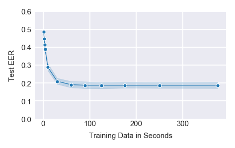

```python
utils_plot_training_delay(df_plot)
utils_save_plot(plt, REPORT_PATH / f"buech2019-ocsvm-{P.name.lower()}-train-size.pdf")
```

### 4.4 Evaluate increasing Test Set Sizes (Detection Delay)

```python
df_results = None  # Will be filled with cv scores
for i in tqdm(range(20), desc="Run", leave=False):
    for df_cv_scenarios, owner, impostors in tqdm(
        utils_generate_cv_scenarios(
            df_train_test,
            samples_per_subject_train=P.samples_per_subject_train,
            samples_per_subject_test=P.samples_per_subject_test,
            limit_test_samples=1,  # Samples overall
            seed=SEED + i,  # Change seed for different runs
            scaler=P.scaler,
            scaler_global=P.scaler_global,
            scaler_scope=P.scaler_scope,
            feature_cols=P.feature_cols,
        ),
        desc="Owner",
        total=df_train_test["subject"].nunique(),
        leave=False,
    ):
        X = np.array(df_cv_scenarios["X"].values.tolist())
        X = X.reshape(X.shape[-3], -1)  # flatten windows
        y = df_cv_scenarios["label"].values
        train_test_cv = utils_create_cv_splits(df_cv_scenarios["mask"].values, SEED)

        model = OneClassSVM(kernel="rbf", nu=P.ocsvm_nu, gamma=P.ocsvm_gamma)

        scores = cross_validate(
            model,
            X,
            y,
            cv=train_test_cv,
            scoring={"eer": utils_eer_scorer},
            n_jobs=CORES,
            verbose=0,
            return_train_score=True,
        )
        df_score = pd.DataFrame(scores)
        df_score["owner"] = owner
        df_score["train_eer"] = df_score["train_eer"].abs()  # Revert scorer's signflip
        df_score["test_eer"] = df_score["test_eer"].abs()
        df_results = pd.concat([df_results, df_score], axis=0)

df_results.to_csv(OUTPUT_PATH / f"{P.name}_detect_delay_results.csv", index=False)
df_results.head()
```

|  | fit_time | score_time | test_eer | train_eer | owner |
| --- | --- | --- | --- | --- | --- |
| 0 | 0.000000 | 0.0 | 0.0 | 1.818989e-12 | 808022 |
| 1 | 0.000000 | 0.0 | 0.0 | 1.818989e-12 | 808022 |
| 2 | 0.000000 | 0.0 | 0.0 | 1.818989e-12 | 808022 |
| 3 | 0.000000 | 0.0 | 0.5 | 1.818989e-12 | 808022 |
| 4 | 0.015622 | 0.0 | 0.5 | 1.818989e-12 | 808022 |

**Load Results from "Detection Delay" evaluation & prepare for plotting:**

```python
df_results = pd.read_csv(OUTPUT_PATH / f"{P.name}_detect_delay_results.csv")
df_results["owner"] = df_results["owner"].astype(str)
df_plot = df_results.copy()
```

**Plot Expanding Mean EER and confidence interval:**

```
Mean samples: 32.8
Mean seconds: 16.4
```

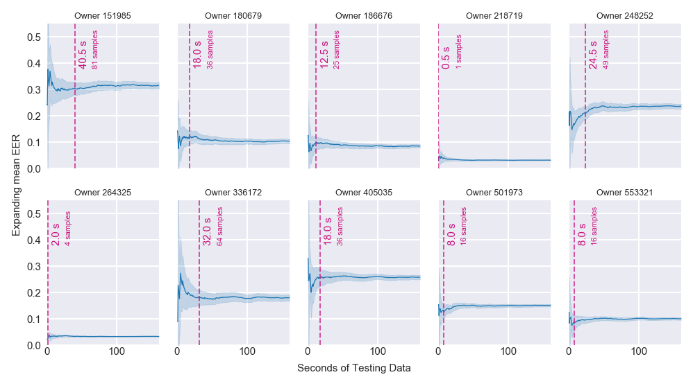

```python
utils_plot_detect_delay(df_plot, factor=P.window_size / P.frequency, xlim=160)
utils_save_plot(plt, REPORT_PATH / f"buech2019-ocsvm-{P.name.lower()}-detection-delay.pdf")
```